# FIFA2019 Taller 1 Evaluable

Ricardo Alberich; Juan Gabriel Gomila

30 de mayo de 2019

# 1 Preguntas:

Hay que subir a la actividad el Rmd y el HTML con los nombres del los estudiantes y lo que se pide

Con vuestros datos del proyecto final realizar los siguientes análisis:

1. Seleccionar un factor F de más de tres niveles y menos 5 ( si es posible) y una variable cuantitativa X (continua).
   1. Para cada nivel del factor F hacer un test KS de normalidad para contrastar que la distribución de X sea normal (de media y desviación típica la que corresponda a cada muestra).
   2. Hacer un boxplot de X para cada nivel de F.
   3. Utilizad el la función `bartlet.test` para contrastar la homodedasticidad de X en cada nivel del factor F. (Consultad AprendeR2)[https://aprender-uib.github.io/AprendeR2/chap-ANOVA.html#metodos-no-parametricos]
   4. Realizar una ANOVA.
   5. Comparación de medias dos a dos con ajuste de Bonferrori.
2. Escoge dos o tres variables cuantitativas X1,X2,X3
1. Clustering por k-means en 4 clases, extraer el cluster de cada observación
2. Haz un Boxplot para cada una de las variables para cada cluster.
3. Dibujad un matrixplot de las tres variables coloreando por cluster.

## 1.1 Ejemplo del FIFA

En [FIFA 19 complete player dataset 18k+ FIFA 19 players, ~90 attributes extracted from the latest FIFA database](https://www.kaggle.com/karangadiya/fifa19#data.csv)

Tenemos acceso al data set de los jugadores del videojuego FIFA 2019. La información que aporta la página es la siguiente (para más información acudid a la página):

*About this file*

*data.csv includes lastest edition FIFA 2019 players attributes like Age, Nationality, Overall, Potential, Club, Value, Wage, Preferred Foot, International Reputation, Weak Foot, Skill Moves, Work Rate, Position, Jersey Number, Joined, Loaned From, Contract Valid Until, Height, Weight, LS, ST, RS, LW, LF, CF, RF, RW, LAM, CAM, RAM, LM, LCM, CM, RCM, RM, LWB, LDM, CDM, RDM, RWB, LB, LCB, CB, RCB, RB, Crossing, Finishing, Heading, Accuracy, ShortPassing, Volleys, Dribbling, Curve, FKAccuracy, LongPassing, BallControl, Acceleration, SprintSpeed, Agility, Reactions, Balance, ShotPower, Jumping, Stamina, Strength, LongShots, Aggression, Interceptions, Positioning, Vision, Penalties, Composure, Marking, StandingTackle, SlidingTackle, GKDiving, GKHandling, GKKicking, GKPositioning, GKReflexes, and Release Clause.*

## 1.2 Carga de los datos

Cargamos los datos y los visualizamos

```r
data=read.csv("data.csv",stringsAsFactors = FALSE)
#head(data)
#str(data)
```

```r
clubs=c("FC Barcelona", "Real Madrid", "Manchester City","Paris Saint-Germain")
clubs
```

```
## [1] "FC Barcelona"        "Real Madrid"         "Manchester City"
## [4] "Paris Saint-Germain"
```

```r
data2=data[data$Club%in% clubs,c("Club", "Name","Penalties", "Marking", "Interceptions")]
head(data2)
```

```
##                  Club         Name Penalties Marking Interceptions
## 1        FC Barcelona     L. Messi        75      33            22
## 3 Paris Saint-Germain    Neymar Jr        81      27            36
## 5     Manchester City K. De Bruyne        79      68            61
## 7         Real Madrid    L. Modrić        82      60            83
## 8        FC Barcelona    L. Suárez        85      62            41
## 9         Real Madrid Sergio Ramos        75      87            90
```

```r
X=data2$Penalties
F=as.factor(data2$Club)
levels(F)
```

```
## [1] "FC Barcelona"        "Manchester City"     "Paris Saint-Germain"
## [4] "Real Madrid"
```

```r
muestra1=X[F=="FC Barcelona"]
ks.test(muestra1,"pnorm",mean(muestra1),sd(muestra1))
```

```
##
##  One-sample Kolmogorov-Smirnov test
##
## data:  muestra1
## D = 0.11103, p-value = 0.8106
## alternative hypothesis: two-sided
```

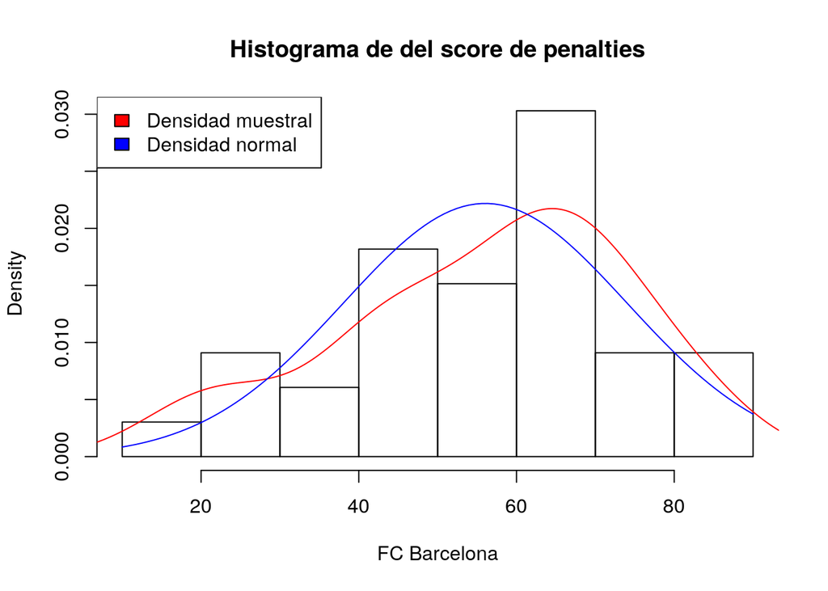

```r
#idem los demás muestras por valor
hist(muestra1,freq =FALSE,main="Histograma de del score de penalties",xlab="FC Barcelona")
lines(density(muestra1),col="red")
curve(dnorm(x,mean(muestra1),sd(muestra1)),add=TRUE,col="blue")
legend("topleft",c("Densidad muestral","Densidad normal"),fill=c("red","blue"))
```

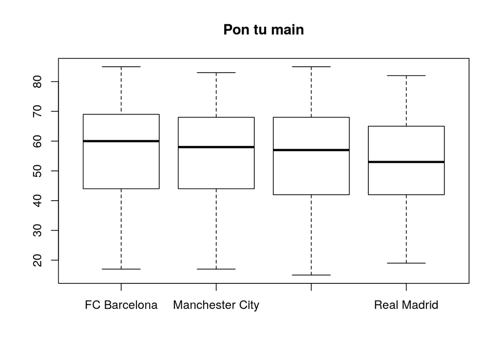

```r
boxplot(X~F,main="Pon tu main")#arreglas las....
```

```r
bartlett.test(X~F)
```

```
##
##  Bartlett test of homogeneity of variances
##
## data:  X by F
## Bartlett's K-squared = 0.086503, df = 3, p-value = 0.9934
```

```r
sola_aov=aov(X~F)
summary(sola_aov)
```

```
##              Df Sum Sq Mean Sq F value Pr(>F)
## F             3    181   60.26   0.196  0.899
## Residuals   125  38513  308.11
```

```r
pairwise.t.test(X,F,p.adjust.method = "bonferroni")
```

```
##
##  Pairwise comparisons using t tests with pooled SD
##
## data:  X and F
##
##                     FC Barcelona Manchester City Paris Saint-Germain
## Manchester City     1            -               -
## Paris Saint-Germain 1            1               -
## Real Madrid         1            1               1
##
## P value adjustment method: bonferroni
```

```r
cluster4=kmeans(data2[,3:5],centers = 4)
table(cluster4$cluster,F)
```

```
##    F
##     FC Barcelona Manchester City Paris Saint-Germain Real Madrid
##   1            9               8                   7           9
##   2           14              13                  12          12
##   3            4               4                   3           4
##   4            6               8                   8           8
```

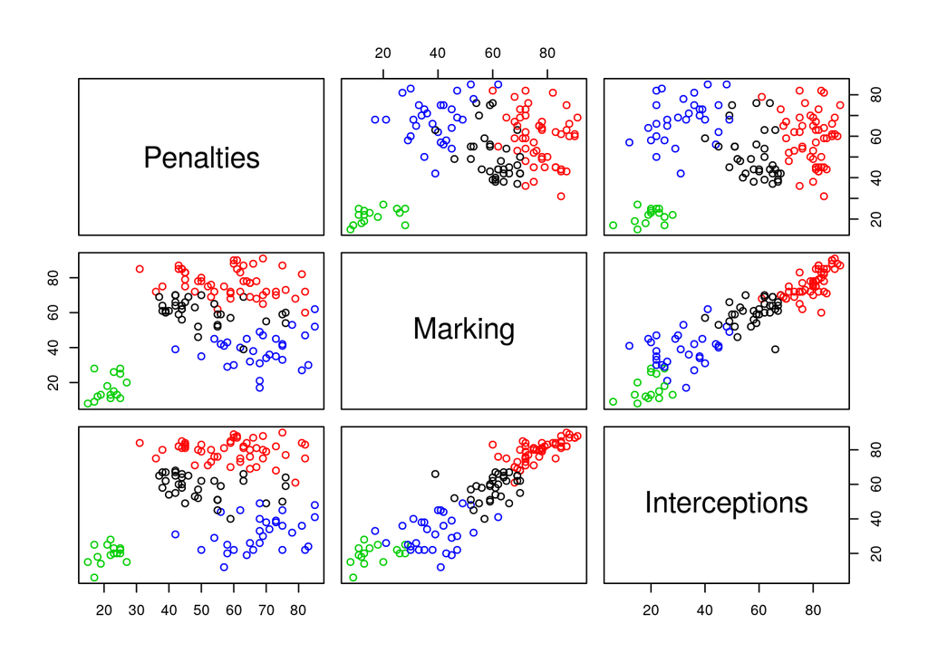

```r
plot(data2[,3:5],col=cluster4$cluster)
```

```r
estadisticos=function(x) c(media=mean(x),sd=sd(x),min=min(x),mediana=median(x),max=max(x))

aggregate(data2[,3],list(cluster4$cluster),estadisticos)
```

```
##   Group.1   x.media      x.sd     x.min x.mediana     x.max
## 1       1 50.363636 11.475022 37.000000 46.000000 76.000000
## 2       2 58.941176 12.424833 31.000000 60.000000 82.000000
## 3       3 21.533333  3.583029 15.000000 22.000000 27.000000
## 4       4 67.966667 10.617108 42.000000 68.000000 85.000000
```

```r
aggregate(data2[,4],list(cluster4$cluster),estadisticos)
```

```
##   Group.1   x.media      x.sd     x.min x.mediana     x.max
## 1       1 60.484848  7.080436 39.000000 61.000000 70.000000
## 2       2 77.098039  7.671388 60.000000 77.000000 91.000000
## 3       3 16.666667  7.016986  8.000000 13.000000 28.000000
## 4       4 38.700000  9.649549 17.000000 39.500000 62.000000
```

```r
aggregate(data2[,5],list(cluster4$cluster),estadisticos)
```

```
##   Group.1   x.media      x.sd     x.min x.mediana     x.max
## 1       1 58.545455  7.198485 40.000000 60.000000 68.000000
## 2       2 79.588235  6.122668 61.000000 81.000000 90.000000
## 3       3 19.533333  5.475486  6.000000 20.000000 28.000000
## 4       4 31.666667  9.717859 12.000000 31.500000 49.000000
```